# Python 进阶 (lecture for Solar Group)

## Anaconda

> A **conda package** is a compressed tarball file that contains system-level libraries, Python or other modules, executable programs and other components. **Conda** keeps track of the dependencies between packages and platforms.  
> (https://conda.io/docs/user-guide/concepts.html)
- 凡使用 pip install 安装的包均为编译安装, conda install 安装的则为编译好的二进制包.
- conda 包可以打包其他语言, pip 包容易出现系统依赖问题
- conda 包的依赖管理更完善
- conda 环境下仍可使用 pip 进行安装, 但所使用的 pip 命令和系统中的 pip 互不影响, 安装的包的位置也在 conda 本身的目录下.
- 每个环境互不影响, 各环境下的包虽然必须分别安装 (也可以 clone 一个现有环境),  
  但如果有不同环境中有重复的包 conda 将默认使用 *hard link*.

(更多讨论参考 http://jakevdp.github.io/blog/2016/08/25/conda-myths-and-misconceptions/)

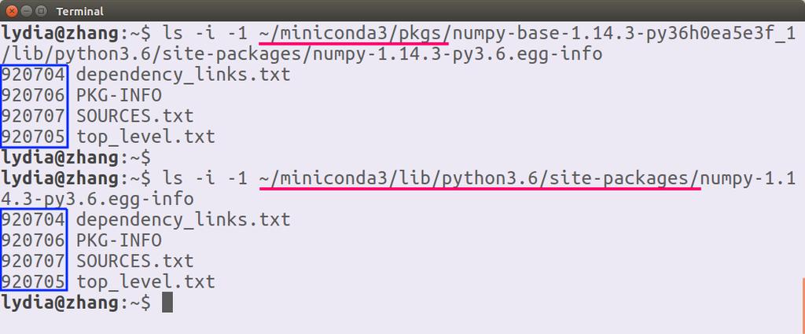

- python 位置 (未使用 conda 时)

使用

```
$ python -m site
```

可以看到有哪些目录.

三个部分:

- **root**

  ```
  /usr/lib/...
  /usr/bin/...
  ```

- **user**

  ```
  /home/<user>/.local/lib/...
  /home/<user>/.local/bin/...
  ```

- **anaconda/miniconda**

  ```
  /home/<user>/miniconda3//lib/...
  /home/<user>/miniconda3//bin/...
  ```

- conda 目录结构 (安装之后自动修改了软连接, 修改环境变量后系统优先使用这个位置)

```
/home/<user>/miniconda3/
    ├── pkgs/
    ├── bin/
    │        ├── python -> python3.6
    │        ├── python3 -> python3.6
    │        ├── python3.6
    │        ├── jupyter
    │        ├── h5dump
    │        └── ...
    ├── include/
    ├── lib/
    ├── share/
    ├── envs
    │        ├── env1/
    │        │        ├── bin/
    │        │        ├── include/
    │        │        ├── lib/
    │        │        ├── share/
    │        │        └── ...
    │        ├── env2/
    │        └── ...
    └── ...
```

## IPython & Jupyter

参考文档 http://jupyter-notebook.readthedocs.io/en/stable/

- 配置文件路径

一般用户配置文件在 `~/.jupyter`

```python
!jupyter --paths
```

```
config:
    /home/lydia/.jupyter
    /home/lydia/miniconda3/etc/jupyter
    /usr/local/etc/jupyter
    /etc/jupyter
data:
    /home/lydia/.local/share/jupyter
    /home/lydia/miniconda3/share/jupyter
    /usr/local/share/jupyter
    /usr/share/jupyter
runtime:
    /run/user/1000/jupyter
```

- 列出所有 magic functions:

```python
%lsmagic
```

- 运行脚本:

```python
%run script.py
%run script.ipynb
```

- 在单个 Cell 中调用其他语言 (子进程):

```python
%%sh
cd ~/miniconda3/
pwd
```

```
/home/lydia/miniconda3
```

可以看到实际并未改变当前目录 (因为是子进程):

```python
pwd
```

```
'/home/lydia/codes/zly/python/python-intro'
```

```python
%%script idl
cd, current=d
print, d
```

```
/home/lydia/codes/zly/python/python-intro
```

```
IDL Version 8.2.1 (linux x86_64 m64). (c) 2012, Exelis Visual Information Solutions, Inc.
```

- 逐行使用 bash 命令 (注意不加 '!' 的区别):

```python
!idl -e field3dgui
```

```python
!ls ./
```

得到的结果可以存入变量:

```python
current, = !pwd  # returns a list
current
```

[output not shown]

下面这两句不能写在一个 Cell 中:

```python
cd -q ~/miniconda3/
```

```python
pwd
```

```
'/home/lydia/miniconda3'
```

用 `{var}` (推荐) 或 `$var` (不推荐) 调用当前 ipython 环境的变量:

```python
cd {current}
```

```
/home/lydia/codes/zly/python/python-intro
```

```python
cd "$current"
```

```
/home/lydia/codes/zly/python/python-intro
```

```python
cd $current
```

```
/home/lydia/codes/zly/python/python-intro
```

见 http://mmcdan.github.io/posts/interacting-with-the-shell-via-jupyter-notebook/ (broken)

- 列出当前的变量信息

```python
a = 1
b = 'x'

%whos int str
```

```
Variable   Type    Data/Info
----------------------------
a          int     1
b          str     x
```

## 语法细节

### python2 & python3

```python
%%python2
print 1 / 2
print 1 // 2
```

```
0
0
```

```python
%%python3
print(1 / 2)
print(1 // 2)
```

```
0.5
0
```

详见 Python 2 -> 3 的转换

### list, tuple

- 对 list 或 tuple, 当只有一个元素时, 注意加逗号:

```python
l = [1]
type(l)
```

```
list
```

```python
l = [1,]
type(l)
```

```
list
```

```python
l = (1)
type(l)
```

```
int
```

```python
l = (1,)
type(l)
```

```
tuple
```

- 赋值, 星号 (`*`) 表达式用来展开 list/tuple, 双星号 (`**`) 用来展开 dict (常用于函数参数表):

```python
a, b, *c = [0, 1, 2, 3]
a, b, c
```

```
(0, 1, [2, 3])
```

```python
a, *_ = [0, 1, 2, 3] # 或 a, = ...
a
```

```
0
```

### dict

- dict 改变某个 key 但 value 不变的方法

```python
d = {'a' : 1, 'b' : 2}
d['c'] = d.pop('b')  # 利用 `pop` 返回值, 更改 key 值
d
```

```
{'a': 1, 'c': 2}
```

- dict 求并集

```python
d1 = {'a' : 1, 'b' : 2}
d2 = {'a' : -1, 'c' : 3, 'd' : 4}
```

```python
dict(d1, **d2)  # 重复的 key 取后一个的值
```

```
{'a': -1, 'b': 2, 'c': 3, 'd': 4}
```

```python
dict(list(d1.items()) + list(d2.items()))  # 注意其中的 list
```

```
{'a': -1, 'b': 2, 'c': 3, 'd': 4}
```

```python
d1.update(d2)
d1
```

```
{'a': -1, 'b': 2, 'c': 3, 'd': 4}
```

### set

- set 基本操作

```python
s = {1, 2}
```

```python
s.add(3) # one element only
s
```

```
{1, 2, 3}
```

```python
s.update([4, 5]) # iterable: list/tuple/set/...
s
```

```
{1, 2, 3, 4, 5}
```

```python
s.remove(1)
s
```

```
{2, 3, 4, 5}
```

```python
s.discard(0)  # No error if not exist
s
```

```
{2, 3, 4, 5}
```

- set 求交集, 并集, 差集, 对称差集, 子集

```python
{1, 2}.intersection({2, 3})
```

```
{2}
```

```python
{1, 2} & {2, 3}  # 或用 and
```

```
{2}
```

```python
{1, 2}.union({2, 3})
```

```
{1, 2, 3}
```

```python
{1, 2} | {2, 3}  # 或用 or
```

```
{1, 2, 3}
```

```python
{1, 2}.difference({2, 3})
```

```
{1}
```

```python
{1, 2} - {2, 3}  # 在前不在后
```

```
{1}
```

```python
{1, 2}.symmetric_difference({2, 3})
```

```
{1, 3}
```

```python
{1, 2} ^ {2, 3}  # 不同时在两边
```

```
{1, 3}
```

- 属于, 包含于(子集)

```python
2 in {1, 2, 3}  # list/tuple/set
```

```
True
```

```python
4 not in {1, 2, 3}  # list/tuple/set
```

```
True
```

```python
{1, 2}.issubset({1, 2, 3})
```

```
True
```

```python
{1, 2} <= {1, 2, 3}
```

```
True
```

```python
{1, 2, 3}.issuperset({1, 2})
```

```
True
```

```python
{1, 2, 3} >= {1, 2}
```

```
True
```

### 一些特性的演示

插件 https://github.com/lgpage/nbtutor  
网页版 http://pythontutor.com/

```python
%reload_ext nbtutor
```

```python
%%nbtutor -r -f
l1= (0)
l2 = (0,)
```

[网页版演示](http://t.cn/Rg9J3bf)

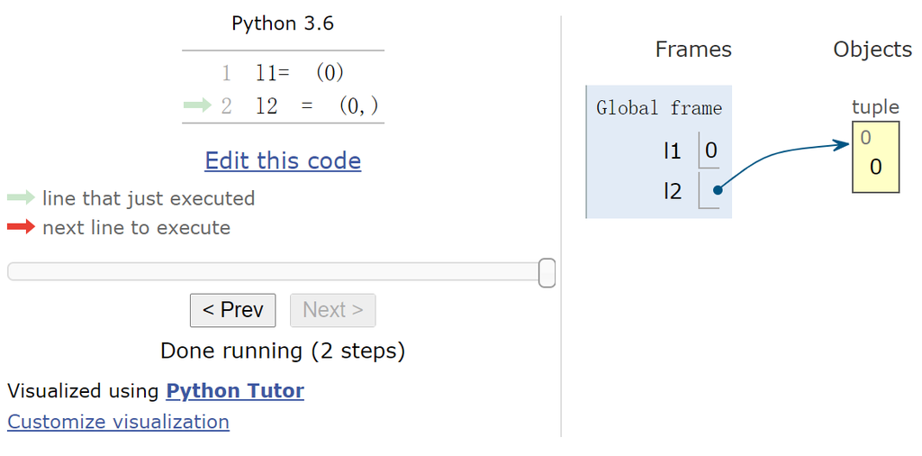

```python
%%nbtutor -r -f -i
a = 3
b = 4
t = (1, 2, [a, b]) # list in tuple
a = 'x' # change element in list
t[2][0] = 'xx' # change element in tuple
```

```python
print(t)
```

[网页版演示](http://t.cn/Rg9idUn)

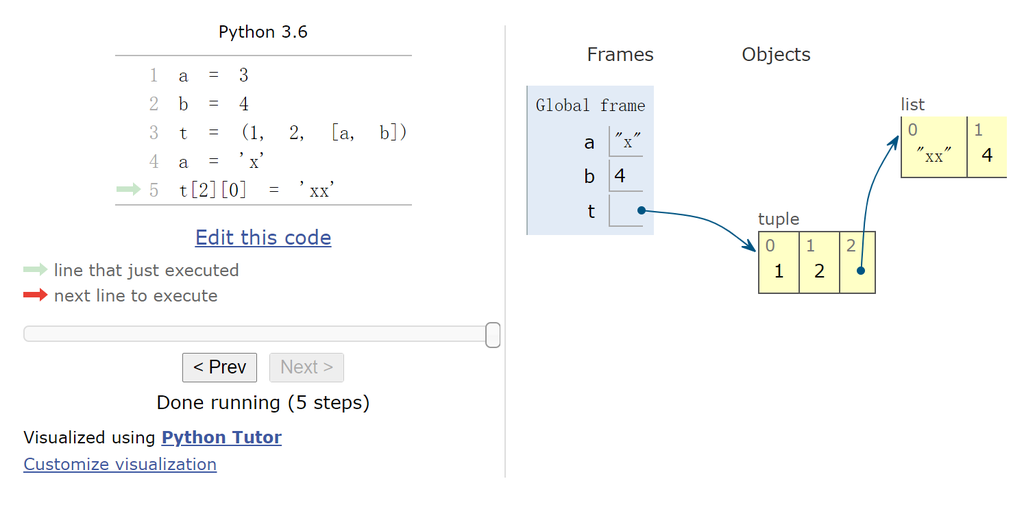

### 包含判断的单行循环

```python
l = [1, 2, 3, 4, 5]
[i for i in l if i > 2]
```

```
[3, 4, 5]
```

例如用 `globals()` 来得到字符串形式的变量名 (python 的变量没有提供这个功能的关键字, 因为"变量名"存储在namespaces中)

```python
def namestr(obj, namespace):
    return [name for name in namespace if namespace[name] is obj][0]
a = 1
b = 2
for var in (a, b):
    print(f'{namestr(var, globals())} = {var}')
```

```
a = 1
b = 2
```

### 单行 if (三元关系运算)

```python
a = 1
b = 'y' if a > 0 else 'n'
b
```

```
'y'
```

### 循环, 迭代器, 生成器

Python 的 for 循环不使用索引变量, 而使用遍历**迭代器** (iterator) 的方式处理**可迭代对象** (range, set 等):

```
for i in range(5):
    ...
```

遍历的方式是使用 `iter` 和 `next` 函数:

```python
a = iter(range(5))  # 生成一个 range_iterator 对象
```

```python
next(a)
```

```
0
```

```python
list(range(5))  # 转换为 list
```

```
[0, 1, 2, 3, 4]
```

`enumerate` 函数适合需要同时使用索引和内容时使用:

```
for i, item in enumerate(l):  # enumerate()是一个迭代器
    i = ...
    item = ...  # l[i] = ...
```

生成器:

```python
a = (i**2 for i in range(5))  # 产生一个生成器, 可转化成 list, tuple
a
```

```
<generator object <genexpr> at 0x14da87e652b0>
```

```python
next(a)  # 生成器也是迭代器
```

[output not shown]

```python
a = [i for i in range(3)]  # 产生一个 list
a
```

```
[0, 1, 2]
```

```python
# 转化成 tuple
tuple(i for i in range(3))
```

```
(0, 1, 2)
```

### 函数定义

- 一般的函数定义:

```
def func(a, b, *args, **kwargs):
    # func1(x, y, arg1, arg2, ..., key1=val1, key2=val2, ...)
    ...
    return ... # 没有 return 或为空 则返回 None
```

- 单行函数 lambda

```python
def f(x, y):
    return x + y
f(1, 2)
```

```
3
```

用 `lambda` 语法来定义:

```python
f = lambda x, y: x + y
f(1, 2)
```

```
3
```

```python
(lambda x, y: x + y)(1, 2)  # 不一定需要定义函数名称
```

```
3
```

### 命名空间和变量作用域

https://sebastianraschka.com/Articles/2014_python_scope_and_namespaces.html

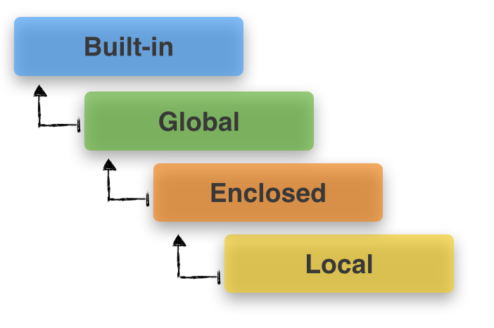

- Built-in Functions https://docs.python.org/3/library/functions.html
- Built-in Constants https://docs.python.org/3/library/constants.html

`globals()` 以 dict 形式返回当前所有全局变量, 包括导入的包名, ipython/jupyter 的 `In`, `Out` 等.  
python 以 name -> obj 的形式存储这些变量.

```python
a = 1
b = 2
```

```python
globals()['a'] is a
```

```
True
```

```python
i = 1
def f():
    i = 2
    print(i, 'local')
    return
f()
print(i, 'global')
```

```
2 local
1 global
```

```python
i = 1
for i in range(4):
    pass
i  # 值被改变了 (“leaking”)
```

```
3
```

```python
i = 1
[i for i in range(3)]
i  # 用这种方式就不会发生“leaking”
```

```
1
```

有关函数中的变量作用方式细节, 参考这里提到的例子: [stackoverflow](https://stackoverflow.com/a/575887)

> - Any time you see **varname =**, you're **creating a new name** binding within the function's scope.  
>   Whatever value `varname` was bound to before is lost within this scope.
> - Any time you see **varname.foo()**, you're **calling a method** on `varname`. The method may alter `varname` (e.g. `list.append`).  
>   `varname` (or, rather, the object that `varname` names) may exist in more than one scope, and since it's the same object,  
>   **any changes will be visible in all scopes**.

## NumPy

### numpy 的数据类型 dtype

https://www.tutorialspoint.com/numpy/numpy_data_types.htm

```
>>> np.dtype(np.int64) is np.dtype('i8') is np.dtype('<i8')
True
>>> np.dtype(np.int64) is np.dtype('int') is np.dtype('int64')
True
>>> np.dtype(np.int64) is np.dtype('>i8')
False
```

```
>>> np.dtype(np.float64) is np.dtype('f8') is np.dtype('<f8')
True
>>> np.dtype(np.float64) is np.dtype('float') is np.dtype('float64')
True
```

见 Fortran 二进制文件读写 中的应用.

### np.arange 参数为浮点数时要注意的细节

```python
np.arange(0., 1.8, 0.3)  # 默认不包含 `stop` 这个点
```

```
array([0. , 0.3, 0.6, 0.9, 1.2, 1.5])
```

```python
np.arange(0., 2.1, 0.3)  # 这里却包括了, 为什么?
```

```
array([0. , 0.3, 0.6, 0.9, 1.2, 1.5, 1.8, 2.1])
```

```python
'%.16f' % 2.1  # 因为浮点数计算方式产生的精度问题
```

```
'2.1000000000000001'
```

看一个求和的例子中同样的问题 (用 `list` 和 `numpy.ndarray` 效果一样):

```python
print('%.17f' % 0.1)
# sum([0.1, ..., 0.1])

print('%.17f' % sum([0.1] * 10))
# 因为同样问题, 累积了误差

import math
print('%.17f' % math.fsum([0.1] * 10))
```

```
0.10000000000000001
0.99999999999999989
1.00000000000000000
```

```python
sum([0.1] * 10) == 1
```

```
False
```

```python
math.fsum([0.1] * 10) == 1
```

```
True
```

```python
math.fsum([0.1] * 10) == 1.0
```

```
True
```

参考 https://docs.python.org/3/tutorial/floatingpoint.html

建议是: 使用整数; 对浮点数的情况, stop 值设得略小一些 (比如减去步长的一般) 以防止改点被包含, 或使用 `np.linspace` 代替.

### 矩阵

`np.matrix`(矩阵) 是 `np.ndarray`(数组) 的一个子类, 继承了父级的方法, 也定义了新的方法 (例如矩阵运算).

```python
issubclass(np.matrix, np.ndarray)
```

```
True
```

```python
a = np.matrix([[0, 1, 2], [3, 4, 5]]); a
```

```
matrix([[0, 1, 2],
        [3, 4, 5]])
```

```python
a = np.matrix("0 1 2; 3 4 5"); a
```

```
matrix([[0, 1, 2],
        [3, 4, 5]])
```

```python
type(a)
```

```
numpy.matrixlib.defmatrix.matrix
```

`np.asmatrix` (或简写作 `np.mat`) 相当于 `np.matrix(data, copy=False)`

```python
x = np.array([[1, 2], [3, 4]])
m = np.matrix(x)
m[0, 0] = 5
x
```

```
array([[1, 2],
       [3, 4]])
```

```python
x = np.array([[1, 2], [3, 4]])
m = np.mat(x)
m[0, 0] = 5
x
```

```
array([[5, 2],
       [3, 4]])
```

```python
x.__array_interface__['data'][0] == m.__array_interface__['data'][0]
```

```
True
```

注意: `np.matrix` 既是一个类名也是一个函数名, 而 `np.mat`, `np.asmatrix` 只是函数名.

### 数组和矩阵运算

#### 数组运算

```python
a = np.arange(12).reshape(3, -1); a
```

```
array([[ 0,  1,  2,  3],
       [ 4,  5,  6,  7],
       [ 8,  9, 10, 11]])
```

```python
a.max()
```

```
11
```

```python
a * a  # 注意这是对应位置的元素间的运算
```

```
array([[  0,   1,   4,   9],
       [ 16,  25,  36,  49],
       [ 64,  81, 100, 121]])
```

```python
a ** 2  # 注意这是对应位置的元素间的运算
```

```
array([[  0,   1,   4,   9],
       [ 16,  25,  36,  49],
       [ 64,  81, 100, 121]])
```

#### 使用数组进行矩阵运算

`scipy.linalg` 与 `numpy.linalg` 的比较: https://scipy.github.io/devdocs/tutorial/linalg.html

> - `scipy.linalg` contains **all** the functions in `numpy.linalg` plus some other more **advanced** ones not contained in `numpy.linalg`
> - Despite its convenience, the use of the `numpy.matrix` class is **discouraged**.
> - `scipy.linalg` operations can be applied **equally** to `numpy.matrix` or to 2D `numpy.ndarray` objects.

```python
a = np.diagflat([1., 2., 3.]); a
```

```
array([[1., 0., 0.],
       [0., 2., 0.],
       [0., 0., 3.]])
```

```python
b = np.array([[-1., -1., -1.],[0., 0., 0.]]); b
```

```
array([[-1., -1., -1.],
       [ 0.,  0.,  0.]])
```

```python
from scipy.linalg import inv
inv(a)  # 求逆
```

```
array([[ 1.        ,  0.        , -0.        ],
       [ 0.        ,  0.5       , -0.        ],
       [ 0.        ,  0.        ,  0.33333333]])
```

```python
a.dot(b.T)  # 矩阵内积
```

```
array([[-1.,  0.],
       [-2.,  0.],
       [-3.,  0.]])
```

#### 直接使用矩阵类型进行运算

使用 numpy 的矩阵类型 `numpy.matrix`

```python
a = np.mat(np.diagflat([1., 2., 3.])); a
```

```
matrix([[1., 0., 0.],
        [0., 2., 0.],
        [0., 0., 3.]])
```

```python
b = np.mat(np.array([[-1., -1., -1.],[0., 0., 0.]])); b
```

```
matrix([[-1., -1., -1.],
        [ 0.,  0.,  0.]])
```

```python
a * b.T  # 矩阵内积, 注意与数组的运算符定义不同
```

```
matrix([[-1.,  0.],
        [-2.,  0.],
        [-3.,  0.]])
```

```python
a @ b.T  # 矩阵内积的新写法, python 3.5+
```

```
matrix([[-1.,  0.],
        [-2.,  0.],
        [-3.,  0.]])
```

```python
a.I  # 求逆
```

```
matrix([[ 1.        ,  0.        , -0.        ],
        [ 0.        ,  0.5       , -0.        ],
        [ 0.        ,  0.        ,  0.33333333]])
```